# Single-cell breast atlas: which cells carry the youth-like deviation?

Donor-level pseudobulks by cellular compartment, scored with the GTEx-breast clock unchanged

Pan-cancer aging project

October 24, 2026

# Summary

**Question.** The manuscript’s age-matched deviations come from bulk RNA-seq, which mixes malignant cells with immune and stromal tissue. The purity supplement showed that deviation scales with malignant fraction, consistent with a tumor-intrinsic signal diluted by non-malignant tissue, but bulk data cannot separate the compartments. Here a single-cell breast cancer atlas is used to build them: for each donor, one pseudobulk profile from all cells, one from epithelial cells (the tumor compartment), one from everything else (immune and stroma), and one from inferCNV-flagged malignant cells. The GTEx-breast clock, its reference and ClockSHAP are applied to each profile exactly as to SCAN-B, with no refitting.

**Design rule.** A 10x pseudobulk is not bulk RNA-seq. The clock’s absolute output on it carries a platform offset that turns out to be study-specific and about 40 years wide. Absolute deviations are therefore reported but not interpreted; the result is the difference between compartments *within a donor*, where the offset cancels.

**Findings (run of 2026-10-15; 64 aged donors from four studies).**

1. In 64 of 64 donors, the epithelial compartment is more youth-like than the donor’s own non-epithelial cells (median difference −32 years; Wilcoxon signed-rank p ≈ 10⁻¹²). For inferCNV-flagged malignant cells, 49 of 49 (median −36). The mixed all-cell profile sits between. This holds in each study separately.
2. Deviation of the all-cell profile scales with the counted epithelial fraction (ρ = −0.65; −3.4 years per 10 points after study adjustment), the single-cell version of the bulk purity relationship (ρ = −0.57; −2.9 per 10 points).
3. PAM50 structure survives in the tumor compartment at the coarse level the sample size allows: Normal-Like and luminal A least youth-like, luminal B, HER2-enriched and basal-like most (Kruskal–Wallis p = 0.001 after study adjustment).
4. Record only: the compartment gap is carried about two-thirds by immune and stromal programs reading older-like in non-epithelial cells and one-third by proliferative and metabolic programs reading more youth-like in tumor cells, the same split the purity pathway analysis found.

**Reading.** The bulk deviation is a diluted view of a signal concentrated in the tumor cells. This answers the composition limitation directly.

**Outputs.** Three panels (paired compartment deviations per donor; all-cell deviation against epithelial fraction; epithelial-compartment deviation by PAM50) and a per-profile CSV of deviations. Some panels may not appear in the published manuscript. Panels are assembled and typeset in Adobe Illustrator. The pathway-contribution sections are record only.

**Caveats.** Absolute levels are not interpretable (platform offset). The inferCNV flag is specific but recovers only about half of author-called cancer cells, so “epithelial” is the primary tumor compartment and the flagged set the stricter check. 64 donors; PAM50 subtypes have 4–19 each. Dissociated tissue over-represents immune cells relative to bulk.

```r
suppressPackageStartupMessages({
  library(dplyr); library(tibble); library(tidyr); library(stringr)
  library(ggplot2); library(knitr); library(Matrix)
  library(Seurat)
  library(edgeR); library(msigdbr); library(GSVA)
  library(glmnet); library(AnnotationDbi); library(org.Hs.eg.db)
  library(ClockSHAP)
})
msg   <- function(...) if (isTRUE(params$verbose)) message(...)
fmt_p <- function(p) ifelse(is.na(p), NA_character_, ifelse(p < 1e-4, formatC(p, format = "e", digits = 1), formatC(p, format = "f", digits = 4)))
```

# Data and processing

## Official BRCA clock objects

The Step-02 clock, the GTEx scores, the ClockSHAP bundle (clock + reference), and the GTEx anchoring fit, loaded as in the SCAN-B processing script.

```r
analysis_id <- paste0(params$tcga_project, "__", params$gtex_project)
suffix      <- paste0("-", params$feature_set)
proc_dir    <- file.path(params$out_root, analysis_id)
clock_rds       <- file.path(proc_dir, paste0("clock_and_RAA_objects", suffix, ".rds"))
scores_gtex_rds <- file.path(proc_dir, paste0("ssgsea_scores_gtex", suffix, ".rds"))
scores_nt_rds   <- file.path(proc_dir, paste0("ssgsea_scores_nt",   suffix, ".rds"))
scores_pt_rds   <- file.path(proc_dir, paste0("ssgsea_scores_pt",   suffix, ".rds"))
clockshap_rds   <- file.path(proc_dir, paste0("clockshap_objects",  suffix, ".rds"))
stopifnot(file.exists(clock_rds), file.exists(scores_gtex_rds), file.exists(clockshap_rds))

clock_results    <- readRDS(clock_rds)
scores_gtex      <- readRDS(scores_gtex_rds)
scores_nt        <- if (file.exists(scores_nt_rds)) readRDS(scores_nt_rds) else NULL
scores_pt        <- if (file.exists(scores_pt_rds)) readRDS(scores_pt_rds) else NULL
clockshap_bundle <- readRDS(clockshap_rds)
feat      <- clock_results$feature_names
clock_cs  <- clockshap_bundle$clock
reference <- clockshap_bundle$reference

pred_gtex <- clock_results$pred$GTEx
age_gtex  <- clock_results$age$GTEx[names(pred_gtex)]
ok_g      <- complete.cases(pred_gtex, age_gtex)
bias_fit  <- lm(pred_gtex[ok_g] ~ age_gtex[ok_g])
beta0 <- unname(coef(bias_fit)[1]); beta1 <- unname(coef(bias_fit)[2])
```

## Atlas: donors, epithelial cells, malignancy flags

The atlas (Andrew’s project, read only) is 621,200 cells from 136 donors across eight studies; 72 donors have a recorded age, all from four studies (Pal 2021, Wu 2021, Wang 2024, Liu 2023). The epithelial object defines the epithelial compartment by cell ID and carries age, study and the donor PAM50 label; the inferCNV table supplies the malignancy flags.

```r
epi <- readRDS(params$atlas_epi_rds)
md_epi <- epi@meta.data
md_epi$cell_key <- as.character(md_epi[["Cell Id"]])
epi_cell_ids <- md_epi$cell_key
rm(epi); invisible(gc())

cnv <- readRDS(params$atlas_cnv_rds)
cnv$cell_key <- as.character(cnv$cell_id)
flags <- md_epi %>%
  dplyr::select(cell_key, donor = donor_id) %>%
  dplyr::left_join(cnv %>% dplyr::select(cell_key, flag_p = dplyr::all_of(params$flag_primary), flag_s = dplyr::all_of(params$flag_sensitivity)), by = "cell_key") %>%
  dplyr::mutate(matched = !is.na(flag_p), mal_p = matched & as.logical(flag_p), mal_s = matched & as.logical(flag_s))

donor_tbl <- md_epi %>%
  dplyr::group_by(donor = donor_id) %>%
  dplyr::summarise(age_years = suppressWarnings(as.numeric(dplyr::first(age))),
                   study     = dplyr::first(batch),
                   pam50     = { t <- table(Pam50, useNA = "no"); if (length(t)) names(t)[which.max(t)] else NA_character_ },
                   .groups = "drop") %>%
  dplyr::mutate(pam50 = dplyr::recode(pam50, "Normal" = "Normal-Like"), pam50 = ifelse(is.na(pam50), "Unclassified", pam50))
knitr::kable(donor_tbl %>% dplyr::count(study, has_age = !is.na(age_years)), caption = "Donors per study, by age availability.")
```

Donors per study, by age availability.

| study | has_age | n |
| --- | --- | --- |
| bassez_2021 | FALSE | 31 |
| gao_2021 | FALSE | 4 |
| liu_2023 | TRUE | 4 |
| pal_2021 | FALSE | 3 |
| pal_2021 | TRUE | 30 |
| qian_2020 | FALSE | 14 |
| tietscher_2023 | FALSE | 12 |
| wang_2024 | TRUE | 14 |
| wu_natgen_2021 | TRUE | 24 |

```r
rm(md_epi, cnv); invisible(gc())
```

## Compartments and pseudobulk

Per aged donor: `all` (every cell), `epithelial` (cells in the epithelial object), `nonepi` (every other cell), `malignant_p` / `malignant_s` (epithelial cells flagged by the primary / sensitivity inferCNV flag). Pseudobulk is the sum of raw counts. A donor is kept if its epithelial and non-epithelial compartments meet the cell thresholds; a malignant profile is kept if it does.

```r
all_obj <- readRDS(params$atlas_all_rds)
md_all  <- all_obj@meta.data
md_all$cell_key <- sub("^_", "", rownames(md_all))        # full-atlas cell names = epithelial `Cell Id` with a leading underscore
stopifnot(!anyDuplicated(md_all$cell_key), mean(epi_cell_ids %in% md_all$cell_key) > 0.99)
cnt_all <- LayerData(all_obj, assay = "RNA", layer = "counts")
gene_ids_all <- rownames(cnt_all)
rm(all_obj); invisible(gc())

md_all$is_epi   <- md_all$cell_key %in% epi_cell_ids
md_all$is_mal_p <- md_all$cell_key %in% flags$cell_key[flags$mal_p]
md_all$is_mal_s <- md_all$cell_key %in% flags$cell_key[flags$mal_s]
md_all$donor    <- as.character(md_all$donor_id)
aged <- md_all$donor %in% donor_tbl$donor[!is.na(donor_tbl$age_years)]
comp_of <- function(sel, name) ifelse(aged & sel, paste0(md_all$donor, "||", name), NA_character_)
groups <- list(
  all         = comp_of(rep(TRUE, nrow(md_all)), "all"),
  epithelial  = comp_of(md_all$is_epi, "epithelial"),
  nonepi      = comp_of(!md_all$is_epi, "nonepi"),
  malignant_p = comp_of(md_all$is_mal_p, "malignant_p"),
  malignant_s = comp_of(md_all$is_mal_s, "malignant_s")
)
pseudobulk <- function(counts, grp) {
  keep <- !is.na(grp); g <- factor(grp[keep])
  ind  <- Matrix::sparse.model.matrix(~ g - 1); colnames(ind) <- levels(g)
  list(counts = as.matrix(counts[, keep, drop = FALSE] %*% ind), n_cells = Matrix::colSums(ind))
}
pb <- lapply(groups, function(g) pseudobulk(cnt_all, g))

composition <- md_all %>% dplyr::filter(aged) %>% dplyr::group_by(donor) %>%
  dplyr::summarise(n_cells_donor = dplyr::n(), n_epi = sum(is_epi), n_nonepi = sum(!is_epi), n_mal_p = sum(is_mal_p),
                   frac_epi = n_epi / n_cells_donor, frac_mal_p = n_mal_p / n_cells_donor, .groups = "drop") %>%
  dplyr::left_join(donor_tbl, by = "donor")
rm(cnt_all, md_all); invisible(gc())

donors_use <- composition %>%
  dplyr::filter(!is.na(age_years), n_epi >= params$min_cells_epithelial, n_nonepi >= params$min_cells_nonepi) %>% dplyr::pull(donor)
keep_col <- function(nm, n_cells) {
  donor <- sub("\\|\\|.*$", "", nm); comp <- sub("^.*\\|\\|", "", nm)
  thr <- c(all = 1, epithelial = params$min_cells_epithelial, nonepi = params$min_cells_nonepi,
           malignant_p = params$min_cells_malignant, malignant_s = params$min_cells_malignant)[comp]
  donor %in% donors_use & n_cells >= thr
}
pb_counts <- do.call(cbind, lapply(pb, function(x) x$counts[, keep_col(colnames(x$counts), x$n_cells), drop = FALSE]))
pb_ncells <- stats::setNames(unlist(lapply(pb, function(x) x$n_cells[keep_col(colnames(x$counts), x$n_cells)]), use.names = FALSE), colnames(pb_counts))
rownames(pb_counts) <- gene_ids_all
stopifnot(!anyDuplicated(colnames(pb_counts)))
pb_meta <- tibble::tibble(profile = colnames(pb_counts),
                          donor = sub("\\|\\|.*$", "", profile),
                          compartment = sub("^.*\\|\\|", "", profile),
                          n_cells = as.numeric(pb_ncells[profile])) %>%
  dplyr::left_join(composition, by = "donor")
knitr::kable(pb_meta %>% dplyr::group_by(compartment) %>%
               dplyr::summarise(profiles = dplyr::n(), min_cells = min(n_cells), median_cells = median(n_cells), max_cells = max(n_cells)),
             caption = "Retained pseudobulk profiles per compartment, and cells per profile.")
```

Retained pseudobulk profiles per compartment, and cells per profile.

| compartment | profiles | min_cells | median_cells | max_cells |
| --- | --- | --- | --- | --- |
| all | 64 | 568 | 5132.5 | 18812 |
| epithelial | 64 | 101 | 2202.0 | 13939 |
| malignant_p | 49 | 103 | 531.0 | 5581 |
| malignant_s | 45 | 101 | 410.0 | 4368 |
| nonepi | 64 | 96 | 1956.5 | 17760 |

## Hallmark ssGSEA, clock, ClockSHAP

The SCAN-B processing functions, unchanged: log-CPM (prior count 1), Ensembl-to-symbol collapse by mean, ssGSEA on the 50 Hallmark sets (alpha 0.25, no normalization); then the clock and ClockSHAP with the GTEx reference.

```r
.hallmark_sets <- local({
  nice <- function(x) x |> stringr::str_remove("^HALLMARK_") |> stringr::str_replace_all("_", " ") |> stringr::str_to_title()
  hall_raw <- msigdbr::msigdbr(species = "Homo sapiens", category = "H")
  split(hall_raw$gene_symbol, nice(hall_raw$gs_name))
})
.ensembl_to_symbol <- function(ensembl_ids) {
  syms <- AnnotationDbi::mapIds(org.Hs.eg.db, keys = sub("\\.\\d+$", "", ensembl_ids), keytype = "ENSEMBL", column = "SYMBOL", multiVals = "first")
  names(syms) <- ensembl_ids; syms
}
.collapse_to_symbols <- function(logcpm, symbols) {
  keep <- !is.na(symbols) & symbols != ""
  summed <- rowsum(logcpm[keep, , drop = FALSE], group = symbols[keep])
  sweep(summed, 1, as.numeric(table(symbols[keep])[rownames(summed)]), "/")
}
.run_ssgsea <- function(expr) GSVA::gsva(GSVA::ssgseaParam(exprData = expr, geneSets = .hallmark_sets, minSize = 1, maxSize = Inf, alpha = 0.25, normalize = FALSE), verbose = FALSE)

logcpm     <- edgeR::cpm(pb_counts, log = TRUE, prior.count = 1)
symbols    <- if (all(grepl("^ENSG", head(rownames(logcpm), 100)))) .ensembl_to_symbol(rownames(logcpm)) else rownames(logcpm)
logcpm_sym <- .collapse_to_symbols(logcpm, symbols)
scores_pb  <- .run_ssgsea(logcpm_sym)
stopifnot(all(feat %in% rownames(scores_pb)))

X_pb  <- t(scores_pb[feat, , drop = FALSE])
ids   <- rownames(X_pb)
age_v <- stats::setNames(pb_meta$age_years[match(ids, pb_meta$profile)], ids)
pred_raw <- as.numeric(predict(clock_results$enet_model, newx = X_pb, s = clock_results$tuning$best_lambda))
cs_pb    <- ClockSHAP::clockshap(features = X_pb, age = age_v, clock = clock_cs, reference = reference)
stopifnot(max(abs(rowSums(cs_pb$phi) - cs_pb$deviation)) < 1e-6)

res <- pb_meta %>%
  dplyr::mutate(predicted     = pred_raw[match(profile, ids)],
                deviation     = as.numeric(cs_pb$deviation)[match(profile, rownames(cs_pb$phi))],
                pred_anchored = predicted - beta0 + (1 - beta1) * age_years,
                compartment   = factor(compartment, levels = c("all", "epithelial", "malignant_p", "malignant_s", "nonepi")),
                pam50         = factor(pam50, levels = c("Normal-Like", "LumA", "LumB", "Her2", "Basal", "Unclassified")))
knitr::kable(res %>% dplyr::group_by(compartment) %>%
               dplyr::summarise(profiles = dplyr::n(), mean_dev = mean(deviation), median_dev = median(deviation), sd_dev = sd(deviation)),
             digits = 1, caption = "Age-matched deviation per compartment. Absolute level reported, not interpreted (see platform check).")
```

Age-matched deviation per compartment. Absolute level reported, not interpreted (see platform check).

| compartment | profiles | mean_dev | median_dev | sd_dev |
| --- | --- | --- | --- | --- |
| all | 64 | -1.2 | 3.3 | 19.5 |
| epithelial | 64 | -17.7 | -18.3 | 16.0 |
| malignant_p | 49 | -22.2 | -22.0 | 13.9 |
| malignant_s | 45 | -22.0 | -21.2 | 12.7 |
| nonepi | 64 | 11.9 | 17.8 | 18.6 |

# Platform check

**Asked.** Does the clock read pseudobulk profiles as it reads bulk tumors, and how large is the platform offset?

**How.** Pseudobulks placed in the Hallmark feature space beside GTEx and TCGA-BRCA; anchored predicted age against chronological age; deviation by study within each compartment.

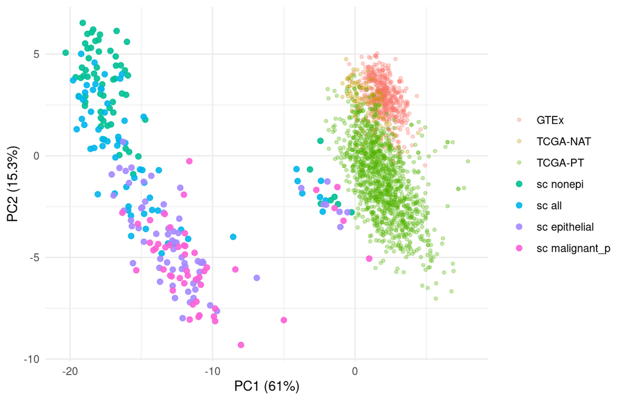

```r
mat_list <- list("GTEx" = scores_gtex, "TCGA-NAT" = scores_nt, "TCGA-PT" = scores_pt)
mat_list <- mat_list[!vapply(mat_list, is.null, logical(1))]
for (cp in c("nonepi", "all", "epithelial", "malignant_p"))
  mat_list[[paste0("sc ", cp)]] <- scores_pb[, pb_meta$profile[pb_meta$compartment == cp], drop = FALSE]
pathways_common <- Reduce(intersect, lapply(mat_list, rownames))
combined <- do.call(cbind, lapply(mat_list, function(m) m[pathways_common, , drop = FALSE]))
cohort   <- rep(names(mat_list), vapply(mat_list, ncol, integer(1)))
pca <- stats::prcomp(t(combined), center = TRUE, scale. = TRUE)
ve  <- round(100 * pca$sdev^2 / sum(pca$sdev^2), 1)
pc_df <- as.data.frame(pca$x[, 1:2]) %>% dplyr::mutate(cohort = factor(cohort, levels = names(mat_list)))
ggplot(pc_df, aes(PC1, PC2, colour = cohort)) +
  geom_point(data = pc_df %>% dplyr::filter(!grepl("^sc ", cohort)), alpha = 0.3, size = 1) +
  geom_point(data = pc_df %>% dplyr::filter(grepl("^sc ", cohort)), alpha = 0.9, size = 1.8) +
  labs(x = paste0("PC1 (", ve[1], "%)"), y = paste0("PC2 (", ve[2], "%)")) +
  theme_minimal(base_size = 11) + theme(legend.title = element_blank())
```

```r
knitr::kable(pc_df %>% dplyr::group_by(cohort) %>% dplyr::summarise(n = dplyr::n(), PC1 = mean(PC1), PC2 = mean(PC2)), digits = 1,
             caption = "Cohort centroids in Hallmark PCA space.")
```

Cohort centroids in Hallmark PCA space.

| cohort | n | PC1 | PC2 |
| --- | --- | --- | --- |
| GTEx | 482 | 2.0 | 2.9 |
| TCGA-NAT | 112 | 0.8 | 2.5 |
| TCGA-PT | 1127 | 2.0 | -1.2 |
| sc nonepi | 64 | -15.9 | 3.0 |
| sc all | 64 | -15.0 | 0.0 |
| sc epithelial | 64 | -11.9 | -4.0 |
| sc malignant_p | 49 | -10.8 | -5.2 |

```r
# raw clock output against chronological age: the slope should match the GTEx training slope (beta1) if the clock's
# age sensitivity transfers to pseudobulk; the intercept is the platform offset and is not interpreted
gtex_df <- tibble::tibble(cohort = "GTEx", age_years = age_gtex[ok_g], predicted = pred_gtex[ok_g])
brca_df <- tibble::tibble(cohort = "TCGA-BRCA", age_years = as.numeric(clock_results$age$Tumour), predicted = as.numeric(clock_results$pred$Tumour)) %>%
  dplyr::filter(complete.cases(age_years, predicted))
sc_df <- res %>% dplyr::filter(compartment %in% c("nonepi", "all", "epithelial", "malignant_p")) %>%
  dplyr::transmute(cohort = paste0("sc ", compartment), age_years, predicted)
knitr::kable(dplyr::bind_rows(gtex_df, brca_df, sc_df) %>% dplyr::group_by(cohort) %>%
               dplyr::summarise(n = dplyr::n(), raw_slope_pred_vs_age = coef(lm(predicted ~ age_years))[2],
                                slope_relative_to_gtex = raw_slope_pred_vs_age / beta1, .groups = "drop"),
             digits = 2, caption = paste0("Raw clock prediction against chronological age (GTEx training slope beta1 = ", round(beta1, 3), ")."))
```

Raw clock prediction against chronological age (GTEx training slope beta1 = 0.178).

| cohort | n | raw_slope_pred_vs_age | slope_relative_to_gtex |
| --- | --- | --- | --- |
| GTEx | 482 | 0.18 | 1.00 |
| TCGA-BRCA | 1117 | 0.01 | 0.06 |
| sc all | 64 | 0.08 | 0.44 |
| sc epithelial | 64 | 0.00 | 0.01 |
| sc malignant_p | 49 | 0.12 | 0.65 |
| sc nonepi | 64 | 0.29 | 1.61 |

```r
knitr::kable(res %>% dplyr::group_by(compartment, study) %>% dplyr::summarise(mean_dev = mean(deviation), .groups = "drop") %>%
               tidyr::pivot_wider(names_from = study, values_from = mean_dev), digits = 1,
             caption = "Mean deviation per compartment and study.")
```

Mean deviation per compartment and study.

| compartment | liu_2023 | pal_2021 | wang_2024 | wu_natgen_2021 |
| --- | --- | --- | --- | --- |
| all | 18.4 | -1.7 | -26.8 | 8.8 |
| epithelial | 5.8 | -16.3 | -39.2 | -12.8 |
| malignant_p | -7.7 | -20.8 | -41.3 | -17.1 |
| malignant_s | -11.7 | -20.9 | -38.9 | -17.6 |
| nonepi | 21.3 | 16.7 | -18.8 | 19.5 |

```r
# Why Wang 2024 sits apart: chemistry is the same as Wu (10x 3' v2), gene coverage and library size match,
# but nearly every Hallmark score is uniformly lower, i.e. a global shift in pathway-score scale (a preprocessing
# property of the deposited matrix). The clock turns that uniform shift into a ~40-year offset through its
# positive-weight pathways. Shown for the non-epithelial compartment, Wang minus Wu, in years.
w_yr <- clock_cs$beta / clock_cs$sigma; names(w_yr) <- feat
sc_ne <- scores_pb[feat, pb_meta$profile[pb_meta$compartment == "nonepi"], drop = FALSE]
st_ne <- pb_meta$study[match(colnames(sc_ne), pb_meta$profile)]
off <- tibble::tibble(pathway = feat, weight_yr_per_unit = as.numeric(w_yr[feat]),
                      score_diff = rowMeans(sc_ne[, st_ne == "wang_2024", drop = FALSE]) - rowMeans(sc_ne[, st_ne == "wu_natgen_2021", drop = FALSE])) %>%
  dplyr::mutate(years = score_diff * weight_yr_per_unit) %>% dplyr::filter(weight_yr_per_unit != 0) %>% dplyr::arrange(years)
knitr::kable(off, digits = c(NA, 4, 0, 1), caption = paste0("Wang - Wu offset by clock pathway (non-epithelial compartment); total ", round(sum(off$years), 1), " years."))
```

Wang - Wu offset by clock pathway (non-epithelial compartment); total -40.3 years.

| pathway | weight_yr_per_unit | score_diff | years |
| --- | --- | --- | --- |
| P53 Pathway | 0.0107 | -2182 | -23.4 |
| Unfolded Protein Response | 0.0046 | -2299 | -10.5 |
| Il2 Stat5 Signaling | 0.0042 | -1341 | -5.6 |
| Tnfa Signaling Via Nfkb | 0.0019 | -2891 | -5.4 |
| Reactive Oxygen Species Pathway | 0.0019 | -2767 | -5.3 |
| Myogenesis | 0.0036 | -1366 | -4.9 |
| Complement | 0.0020 | -1800 | -3.6 |
| Pancreas Beta Cells | -0.0035 | 647 | -2.2 |
| Hypoxia | 0.0013 | -1618 | -2.2 |
| Coagulation | 0.0016 | -1282 | -2.0 |
| Kras Signaling Dn | -0.0011 | 1717 | -1.9 |
| Apoptosis | 0.0003 | -2279 | -0.8 |
| Hedgehog Signaling | 0.0008 | -862 | -0.7 |
| Spermatogenesis | -0.0002 | 1064 | -0.2 |
| Wnt Beta Catenin Signaling | -0.0044 | -570 | 2.5 |
| G2m Checkpoint | -0.0040 | -1017 | 4.1 |
| Uv Response Up | -0.0059 | -1508 | 8.9 |
| Glycolysis | -0.0106 | -1221 | 12.9 |

# Result 1 — Within-donor compartment contrasts

**Asked.** Within a donor, is the tumor compartment more youth-like than the non-epithelial compartment? This is the direct test of dilution; being paired, it is unaffected by the platform offset.

**How.** Deviation of each compartment per donor; differences against `nonepi`; Wilcoxon signed-rank; fraction of donors with the tumor compartment more youth-like. Repeated without Wang 2024 and per study.

```r
wide <- res %>% dplyr::select(donor, study, pam50, frac_epi, frac_mal_p, compartment, deviation) %>%
  tidyr::pivot_wider(names_from = compartment, values_from = deviation)
paired_test <- function(a, b, label) {
  d <- a - b; ok <- is.finite(d)
  w <- suppressWarnings(wilcox.test(a[ok], b[ok], paired = TRUE))
  tibble::tibble(contrast = label, n_donors = sum(ok), median_diff = median(d[ok]), frac_more_youthlike = mean(d[ok] < 0), wilcoxon_p = fmt_p(w$p.value))
}
contrasts <- function(w) dplyr::bind_rows(
  paired_test(w$epithelial,  w$nonepi, "epithelial - nonepi"),
  paired_test(w$malignant_p, w$nonepi, "malignant (primary flag) - nonepi"),
  paired_test(w$malignant_s, w$nonepi, "malignant (sensitivity flag) - nonepi"),
  paired_test(w$all,         w$nonepi, "all cells - nonepi"),
  paired_test(w$malignant_p, w$epithelial, "malignant (primary flag) - epithelial"))
knitr::kable(contrasts(wide), digits = 1, caption = "Within-donor contrasts, all donors (negative = first compartment more youth-like).")
```

Within-donor contrasts, all donors (negative = first compartment more youth-like).

| contrast | n_donors | median_diff | frac_more_youthlike | wilcoxon_p |
| --- | --- | --- | --- | --- |
| epithelial - nonepi | 64 | -32.4 | 1.0 | 3.6e-12 |
| malignant (primary flag) - nonepi | 49 | -35.6 | 1.0 | 3.6e-15 |
| malignant (sensitivity flag) - nonepi | 45 | -36.4 | 1.0 | 5.7e-14 |
| all cells - nonepi | 64 | -10.9 | 0.9 | 3.7e-11 |
| malignant (primary flag) - epithelial | 49 | -2.8 | 0.9 | 4.2e-09 |

```r
knitr::kable(contrasts(wide %>% dplyr::filter(study != "wang_2024")) %>% dplyr::slice_head(n = 2), digits = 1, caption = "Excluding wang_2024.")
```

Excluding wang_2024.

| contrast | n_donors | median_diff | frac_more_youthlike | wilcoxon_p |
| --- | --- | --- | --- | --- |
| epithelial - nonepi | 53 | -33.3 | 1 | 2.5e-10 |
| malignant (primary flag) - nonepi | 41 | -37.1 | 1 | 9.1e-13 |

```r
knitr::kable(wide %>% dplyr::mutate(d = epithelial - nonepi) %>% dplyr::group_by(study) %>%
               dplyr::summarise(n = dplyr::n(), median_diff = median(d), frac_more_youthlike = mean(d < 0), .groups = "drop"),
             digits = 1, caption = "Epithelial - nonepi difference by study.")
```

Epithelial - nonepi difference by study.

| study | n | median_diff | frac_more_youthlike |
| --- | --- | --- | --- |
| liu_2023 | 4 | -13.9 | 1 |
| pal_2021 | 27 | -33.3 | 1 |
| wang_2024 | 11 | -14.6 | 1 |
| wu_natgen_2021 | 22 | -35.9 | 1 |

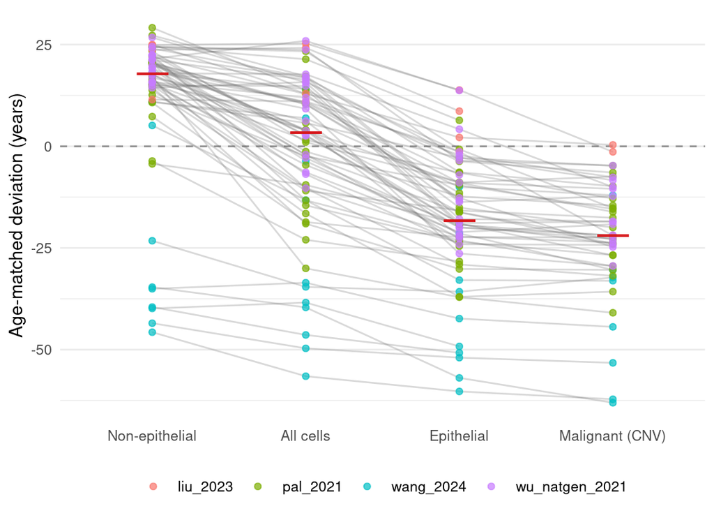

```r
plot_long <- res %>% dplyr::filter(compartment %in% c("nonepi", "all", "epithelial", "malignant_p")) %>%
  dplyr::mutate(compartment = factor(compartment, levels = c("nonepi", "all", "epithelial", "malignant_p"),
                                     labels = c("Non-epithelial", "All cells", "Epithelial", "Malignant (CNV)")))
p_paired <- ggplot(plot_long, aes(compartment, deviation, group = donor)) +
  geom_hline(yintercept = 0, linetype = "dashed", colour = "grey55") +
  geom_line(alpha = 0.25, colour = "grey40") +
  geom_point(aes(colour = study), alpha = 0.7, size = 1.4) +
  stat_summary(aes(group = 1), fun = median, geom = "point", shape = 95, size = 10, colour = "#d7191c") +
  labs(x = NULL, y = "Age-matched deviation (years)") +
  theme_minimal(base_size = 10) + theme(legend.position = "bottom", legend.title = element_blank(), panel.grid.major.x = element_blank())
p_paired
```

**Reading.** Every donor’s epithelial compartment is more youth-like than its non-epithelial compartment (64/64; median −32 years), and every flagged malignant compartment more so (49/49; −36). The all-cell profile lies between. The result is the same without Wang and within each study (100% in each; medians −14 to −36). The flagged malignant set is slightly more youth-like than all epithelial cells (−2.8), as expected if the epithelial pool contains some normal epithelium.

# Result 2 — All-cell deviation against counted tumor fraction

**Asked.** Does the all-cell deviation scale with the fraction of tumor cells, as it scaled with ABSOLUTE purity in bulk? Here the fraction is counted, not estimated.

**How.** All-cell deviation against epithelial fraction: Spearman correlation and linear slope per 10 points, raw, with study in the model, and without Wang 2024.

```r
dev_all <- wide %>% dplyr::filter(is.finite(all))
row_of <- function(d, label, adjust = FALSE) {
  ct <- cor.test(d$all, d$frac_epi, method = "spearman")
  f  <- if (adjust) lm(all ~ frac_epi + study, d) else lm(all ~ frac_epi, d)
  tibble::tibble(version = label, n = nrow(d), spearman_rho = unname(ct$estimate), spearman_p = fmt_p(ct$p.value),
                 slope_per_10pct = 0.1 * coef(f)[["frac_epi"]], slope_p = fmt_p(summary(f)$coefficients["frac_epi", 4]))
}
knitr::kable(dplyr::bind_rows(row_of(dev_all, "raw"), row_of(dev_all, "study-adjusted slope", adjust = TRUE),
                              row_of(dev_all %>% dplyr::filter(study != "wang_2024"), "excluding wang_2024")),
             digits = 2, caption = "All-cell deviation against epithelial fraction. Bulk reference: ABSOLUTE purity in TCGA-BRCA, rho -0.57, -2.9 years per 10 points.")
```

All-cell deviation against epithelial fraction. Bulk reference: ABSOLUTE purity in TCGA-BRCA, rho -0.57, -2.9 years per 10 points.

| version | n | spearman_rho | spearman_p | slope_per_10pct | slope_p |
| --- | --- | --- | --- | --- | --- |
| raw | 64 | -0.65 | 1.7e-08 | -3.67 | 2.0e-06 |
| study-adjusted slope | 64 | -0.65 | 1.7e-08 | -3.37 | 7.5e-08 |
| excluding wang_2024 | 53 | -0.78 | 0.0e+00 | -3.66 | 7.2e-12 |

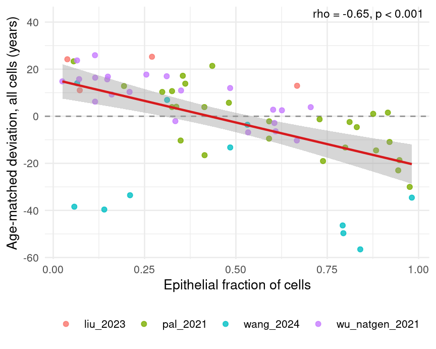

```r
ct <- cor.test(dev_all$all, dev_all$frac_epi, method = "spearman")
p_frac <- ggplot(dev_all, aes(frac_epi, all)) +
  geom_hline(yintercept = 0, linetype = "dashed", colour = "grey55") +
  geom_point(aes(colour = study), alpha = 0.8, size = 1.5) +
  geom_smooth(method = "lm", formula = y ~ x, se = TRUE, colour = "#d7191c", linewidth = 0.8) +
  annotate("text", x = Inf, y = Inf, hjust = 1.05, vjust = 1.3, size = 3,
           label = sprintf("rho = %.2f, %s", ct$estimate, ifelse(ct$p.value < 0.001, "p < 0.001", sprintf("p = %.3f", ct$p.value)))) +
  scale_y_continuous(expand = expansion(mult = c(0.05, 0.25))) +
  labs(x = "Epithelial fraction of cells", y = "Age-matched deviation, all cells (years)") +
  theme_minimal(base_size = 10) + theme(legend.position = "bottom", legend.title = element_blank())
p_frac
```

**Reading.** ρ = −0.65 raw; −3.4 years per 10 points with study in the model; −3.7 (ρ = −0.78) without Wang. Same relationship as bulk purity, with a counted fraction. Wang runs parallel below the fit: an intercept shift, not a different slope.

# Result 3 — PAM50 ordering in the tumor compartment

**Asked.** Does the PAM50 ordering of deviation hold in the epithelial pseudobulk? Subtype counts are small, so ordering and omnibus test only.

**How.** Epithelial-compartment deviation by donor PAM50: raw medians, medians of the residual from `deviation ~ study`, and without Wang 2024; Kruskal–Wallis for each.

```r
epi_df <- res %>% dplyr::filter(compartment == "epithelial", pam50 != "Unclassified") %>%
  dplyr::mutate(pam50 = droplevels(pam50), dev_study_adj = residuals(lm(deviation ~ study)))
knitr::kable(epi_df %>% dplyr::group_by(pam50) %>%
               dplyr::summarise(n = dplyr::n(), median_dev = median(deviation), median_study_adj = median(dev_study_adj),
                                n_no_wang = sum(study != "wang_2024"), median_no_wang = median(deviation[study != "wang_2024"]), .groups = "drop"),
             digits = 1, caption = "Epithelial-compartment deviation by PAM50.")
```

Epithelial-compartment deviation by PAM50.

| pam50 | n | median_dev | median_study_adj | n_no_wang | median_no_wang |
| --- | --- | --- | --- | --- | --- |
| Normal-Like | 4 | 5.3 | 12.5 | 4 | 5.3 |
| LumA | 13 | -11.5 | 9.8 | 10 | -10.2 |
| LumB | 19 | -19.9 | -6.1 | 16 | -19.2 |
| Her2 | 12 | -23.6 | -6.6 | 8 | -19.5 |
| Basal | 16 | -16.9 | -6.0 | 15 | -15.1 |

```r
kw <- c(raw = kruskal.test(deviation ~ pam50, epi_df)$p.value,
        study_adjusted = kruskal.test(dev_study_adj ~ pam50, epi_df)$p.value,
        excluding_wang = kruskal.test(deviation ~ pam50, epi_df %>% dplyr::filter(study != "wang_2024"))$p.value)
knitr::kable(tibble::tibble(version = names(kw), kruskal_wallis_p = fmt_p(kw)), caption = "Kruskal-Wallis across PAM50 subtypes.")
```

Kruskal-Wallis across PAM50 subtypes.

| version | kruskal_wallis_p |
| --- | --- |
| raw | 0.0006 |
| study_adjusted | 0.0014 |
| excluding_wang | 0.0027 |

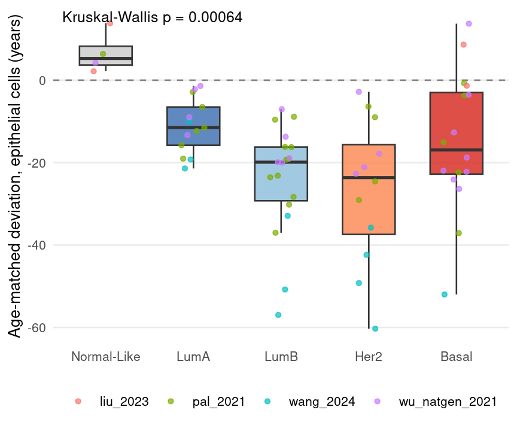

```r
pam50_pal <- c("Normal-Like" = "#cccccc", "LumA" = "#4575b4", "LumB" = "#91bfdb", "Her2" = "#fc8d59", "Basal" = "#d73027")
p_pam50 <- ggplot(epi_df, aes(pam50, deviation, fill = pam50)) +
  geom_hline(yintercept = 0, linetype = "dashed", colour = "grey50") +
  geom_boxplot(width = 0.6, outlier.shape = NA, alpha = 0.85) +
  geom_jitter(aes(colour = study), width = 0.15, alpha = 0.7, size = 1.2) +
  scale_fill_manual(values = pam50_pal, guide = "none") +
  annotate("text", x = -Inf, y = Inf, hjust = -0.05, vjust = 1.3, size = 3.3, label = paste0("Kruskal-Wallis p = ", formatC(kw[["raw"]], format = "g", digits = 2))) +
  labs(x = NULL, y = "Age-matched deviation, epithelial cells (years)") +
  theme_minimal(base_size = 10) + theme(panel.grid.minor = element_blank(), panel.grid.major.x = element_blank(), legend.position = "bottom", legend.title = element_blank())
p_pam50
```

**Reading.** Subtypes differ (p = 6 × 10⁻⁴ raw, 1 × 10⁻³ study-adjusted). After study adjustment the subtypes form two tiers: Normal-Like and luminal A least youth-like, luminal B, HER2-enriched and basal-like most. The order within the second tier is not resolvable at n = 12–19 per subtype.

# Record — pathway contributions by compartment (not used in the manuscript)

Absolute per-pathway contributions carry the platform offset and are not interpretable; the paired epithelial − nonepi difference per pathway is.

```r
phi <- as.data.frame(cs_pb$phi) %>% tibble::rownames_to_column("profile") %>%
  dplyr::left_join(res %>% dplyr::select(profile, donor, compartment), by = "profile")
retained <- feat[colSums(abs(cs_pb$phi[, feat, drop = FALSE])) > 0]
phi_diff <- phi %>% dplyr::filter(compartment %in% c("epithelial", "nonepi")) %>%
  dplyr::select(donor, compartment, dplyr::all_of(retained)) %>%
  tidyr::pivot_longer(dplyr::all_of(retained), names_to = "pathway", values_to = "phi") %>%
  tidyr::pivot_wider(names_from = compartment, values_from = phi) %>%
  dplyr::filter(is.finite(epithelial), is.finite(nonepi)) %>%
  dplyr::group_by(pathway) %>%
  dplyr::summarise(n = dplyr::n(), median_diff = median(epithelial - nonepi),
                   wilcoxon_p = fmt_p(suppressWarnings(wilcox.test(epithelial, nonepi, paired = TRUE))$p.value), .groups = "drop") %>%
  dplyr::arrange(median_diff)
knitr::kable(phi_diff, digits = 1, caption = "Paired epithelial - nonepi contribution per pathway (negative = more youth-like in epithelial cells).")
```

Paired epithelial - nonepi contribution per pathway (negative = more youth-like in epithelial cells).

| pathway | n | median_diff | wilcoxon_p |
| --- | --- | --- | --- |
| Il2 Stat5 Signaling | 64 | -8.3 | 3.6e-12 |
| Glycolysis | 64 | -5.0 | 5.8e-10 |
| Complement | 64 | -4.7 | 3.6e-12 |
| Myogenesis | 64 | -3.8 | 7.2e-10 |
| Tnfa Signaling Via Nfkb | 64 | -3.6 | 4.8e-12 |
| P53 Pathway | 64 | -3.0 | 2.6e-06 |
| Coagulation | 64 | -3.0 | 9.2e-12 |
| G2m Checkpoint | 64 | -2.0 | 2.4e-05 |
| Hypoxia | 64 | -1.0 | 1.0e-09 |
| Reactive Oxygen Species Pathway | 64 | -0.9 | 1.2e-09 |
| Kras Signaling Dn | 64 | -0.7 | 4.1e-10 |
| Hedgehog Signaling | 64 | -0.7 | 2.3e-10 |
| Apoptosis | 64 | -0.4 | 3.6e-12 |
| Spermatogenesis | 64 | -0.1 | 1.8e-11 |
| Unfolded Protein Response | 64 | 0.7 | 1.2e-07 |
| Pancreas Beta Cells | 64 | 0.8 | 0.0004 |
| Uv Response Up | 64 | 1.4 | 4.9e-06 |
| Wnt Beta Catenin Signaling | 64 | 3.5 | 2.6e-08 |

**Reading.** The ~30-year compartment gap is carried about two-thirds by immune and stromal programs reading older-like in non-epithelial cells (IL2/STAT5, complement, TNFα/NFκB, coagulation) and one-third by tumor programs reading more youth-like in epithelial cells (glycolysis, myogenesis, P53, G2M); Wnt runs the other way. This matches the purity pathway analysis, where immune and stromal contributions were purity-dependent and the proliferative/metabolic core was not.

## Within-donor contribution differences, one column per donor

Each cell is the ClockSHAP contribution of a pathway in the donor’s epithelial pseudobulk minus the same pathway in the donor’s non-epithelial pseudobulk, so the platform offset cancels. Blue: more youth-like in the tumor cells than in the donor’s own immune and stromal cells; red: the reverse. Column sums equal the paired deviation difference of Result 1; columns are ordered by it.

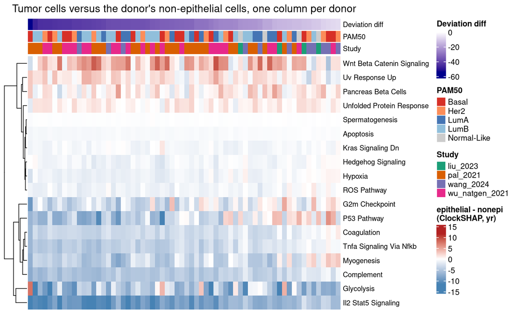

```r
suppressPackageStartupMessages({ library(ComplexHeatmap); library(circlize); library(grid) })
phi_by <- function(cp) {
  r <- res %>% dplyr::filter(compartment == cp)
  m <- cs_pb$phi[r$profile, retained, drop = FALSE]; rownames(m) <- r$donor; m
}
phi_epi <- phi_by("epithelial"); phi_non <- phi_by("nonepi")
donors_d <- intersect(rownames(phi_epi), rownames(phi_non))
diff_mat <- t(phi_epi[donors_d, ] - phi_non[donors_d, ])
rownames(diff_mat)[rownames(diff_mat) == "Reactive Oxygen Species Pathway"] <- "ROS Pathway"
col_meta <- wide %>% dplyr::filter(donor %in% donors_d) %>% dplyr::mutate(diff = epithelial - nonepi) %>% dplyr::arrange(diff)
diff_mat <- diff_mat[, col_meta$donor, drop = FALSE]
stopifnot(max(abs(colSums(diff_mat) - col_meta$diff)) < 1e-6)

pam_cols   <- c("Normal-Like" = "#cccccc", LumA = "#4575b4", LumB = "#91bfdb", Her2 = "#fc8d59", Basal = "#d73027", Unclassified = "grey70")
study_cols <- stats::setNames(c("#1b9e77", "#d95f02", "#7570b3", "#e7298a")[seq_along(unique(res$study))], sort(unique(res$study)))
lim <- as.numeric(stats::quantile(abs(diff_mat), 0.99))
ha  <- ComplexHeatmap::HeatmapAnnotation(
  `Deviation diff` = col_meta$diff, PAM50 = as.character(col_meta$pam50), Study = col_meta$study,
  col = list(`Deviation diff` = circlize::colorRamp2(c(min(col_meta$diff), 0, max(0, max(col_meta$diff))), c("darkblue", "white", "darkred")),
             PAM50 = pam_cols, Study = study_cols),
  annotation_name_gp = grid::gpar(fontsize = 9), annotation_height = grid::unit(rep(3, 3), "mm"))
ht_diff <- ComplexHeatmap::Heatmap(
  diff_mat, name = "epithelial - nonepi\n(ClockSHAP, yr)",
  col = circlize::colorRamp2(c(-lim, 0, lim), c("steelblue", "white", "firebrick")),
  top_annotation = ha, cluster_rows = TRUE, cluster_columns = FALSE,
  show_column_names = FALSE, row_names_gp = grid::gpar(fontsize = 9),
  column_title = "Tumor cells versus the donor's non-epithelial cells, one column per donor")
ComplexHeatmap::draw(ht_diff, heatmap_legend_side = "right", merge_legends = TRUE)
```

**Reading.** Two consistent blocks in essentially every donor: a youth-like block (IL2/STAT5, glycolysis, complement, myogenesis, TNFα/NFκB, coagulation, P53, G2M) and an older-like block (Wnt/β-catenin, UV response up, pancreas β cells, UPR). The six highlighted pathways fall on the sides the bulk decomposition assigned them. Column order is partly study: Pal and Wu carry the largest differences, Wang and Liu smaller ones with a compressed range in every row, so the platform affects the magnitude of the contrast as well as the offset. Sign and pathway identity are study-independent; magnitude is not.

# Save outputs

```r
if (isTRUE(params$save_outputs)) {
  fig_dir_abs <- here::here(params$fig_dir); tables_root_abs <- here::here(params$tables_root)
  dir.create(fig_dir_abs, recursive = TRUE, showWarnings = FALSE); dir.create(tables_root_abs, recursive = TRUE, showWarnings = FALSE)
  utils::write.csv(res, file.path(tables_root_abs, "Supplement_scBRCA_pseudobulk_deviation.csv"), row.names = FALSE)
  ggsave(file.path(fig_dir_abs, "Supplement_scBRCA_paired_compartments.pdf"), p_paired, width = 5, height = 3,    units = "in")
  ggsave(file.path(fig_dir_abs, "Supplement_scBRCA_deviation_vs_fraction.pdf"), p_frac,  width = 5, height = 3,  units = "in")
  ggsave(file.path(fig_dir_abs, "Supplement_scBRCA_PAM50_epithelial.pdf"),     p_pam50, width = 5, height = 3, units = "in")
}
```